# Risk Factor Analysis

## Outcome Variable

**Outcome Variable:** wast_rec90d

## Predictor Variables

**Intervention Variable:** fhtcm

**Adjustment Set:**

- arm
- W_mage
- W_fage
- meducyrs
- feducyrs
- W_mhtcm
- W_mwtkg
- W_mbmi
- single
- delta_W_mage
- delta_W_fage
- delta_meducyrs
- delta_feducyrs
- delta_W_mhtcm
- delta_W_mwtkg
- delta_W_mbmi
- delta_single

## Stratifying Variables

The analysis was stratified on these variable(s):

- agecat
- studyid
- country

## Data Summary

| agecat | studyid | country | fhtcm | wast_rec90d | n_cell | n |
| --- | --- | --- | --- | --- | --- | --- |
| 0-24 months | COHORTS | GUATEMALA | >=167 cm | 0 | 8 | 128 |
| 0-24 months | COHORTS | GUATEMALA | >=167 cm | 1 | 4 | 128 |
| 0-24 months | COHORTS | GUATEMALA | <162 cm | 0 | 62 | 128 |
| 0-24 months | COHORTS | GUATEMALA | <162 cm | 1 | 16 | 128 |
| 0-24 months | COHORTS | GUATEMALA | [162-167) cm | 0 | 30 | 128 |
| 0-24 months | COHORTS | GUATEMALA | [162-167) cm | 1 | 8 | 128 |
| 0-24 months | Keneba | GAMBIA | >=167 cm | 0 | 329 | 1317 |
| 0-24 months | Keneba | GAMBIA | >=167 cm | 1 | 521 | 1317 |
| 0-24 months | Keneba | GAMBIA | <162 cm | 0 | 40 | 1317 |
| 0-24 months | Keneba | GAMBIA | <162 cm | 1 | 64 | 1317 |
| 0-24 months | Keneba | GAMBIA | [162-167) cm | 0 | 131 | 1317 |
| 0-24 months | Keneba | GAMBIA | [162-167) cm | 1 | 232 | 1317 |
| 0-24 months | PROBIT | BELARUS | >=167 cm | 0 | 360 | 3570 |
| 0-24 months | PROBIT | BELARUS | >=167 cm | 1 | 2983 | 3570 |
| 0-24 months | PROBIT | BELARUS | <162 cm | 0 | 15 | 3570 |
| 0-24 months | PROBIT | BELARUS | <162 cm | 1 | 39 | 3570 |
| 0-24 months | PROBIT | BELARUS | [162-167) cm | 0 | 14 | 3570 |
| 0-24 months | PROBIT | BELARUS | [162-167) cm | 1 | 159 | 3570 |
| 0-24 months | SAS-CompFeed | INDIA | >=167 cm | 0 | 117 | 463 |
| 0-24 months | SAS-CompFeed | INDIA | >=167 cm | 1 | 84 | 463 |
| 0-24 months | SAS-CompFeed | INDIA | <162 cm | 0 | 68 | 463 |
| 0-24 months | SAS-CompFeed | INDIA | <162 cm | 1 | 42 | 463 |
| 0-24 months | SAS-CompFeed | INDIA | [162-167) cm | 0 | 96 | 463 |
| 0-24 months | SAS-CompFeed | INDIA | [162-167) cm | 1 | 56 | 463 |
| 0-24 months | SAS-FoodSuppl | INDIA | >=167 cm | 0 | 61 | 223 |
| 0-24 months | SAS-FoodSuppl | INDIA | >=167 cm | 1 | 3 | 223 |
| 0-24 months | SAS-FoodSuppl | INDIA | <162 cm | 0 | 97 | 223 |
| 0-24 months | SAS-FoodSuppl | INDIA | <162 cm | 1 | 5 | 223 |
| 0-24 months | SAS-FoodSuppl | INDIA | [162-167) cm | 0 | 52 | 223 |
| 0-24 months | SAS-FoodSuppl | INDIA | [162-167) cm | 1 | 5 | 223 |

[output cut: 60 more lines]

The following strata were considered:

- agecat: 0-24 months, studyid: COHORTS, country: GUATEMALA
- agecat: 0-24 months, studyid: Keneba, country: GAMBIA
- agecat: 0-24 months, studyid: PROBIT, country: BELARUS
- agecat: 0-24 months, studyid: SAS-CompFeed, country: INDIA
- agecat: 0-24 months, studyid: SAS-FoodSuppl, country: INDIA
- agecat: 0-6 months, studyid: COHORTS, country: GUATEMALA
- agecat: 0-6 months, studyid: Keneba, country: GAMBIA
- agecat: 0-6 months, studyid: PROBIT, country: BELARUS
- agecat: 0-6 months, studyid: SAS-CompFeed, country: INDIA
- agecat: 0-6 months, studyid: SAS-FoodSuppl, country: INDIA
- agecat: 6-24 months, studyid: COHORTS, country: GUATEMALA
- agecat: 6-24 months, studyid: Keneba, country: GAMBIA
- agecat: 6-24 months, studyid: PROBIT, country: BELARUS
- agecat: 6-24 months, studyid: SAS-CompFeed, country: INDIA
- agecat: 6-24 months, studyid: SAS-FoodSuppl, country: INDIA

### Dropped Strata

Some strata were dropped due to rare outcomes:

- agecat: 0-24 months, studyid: COHORTS, country: GUATEMALA
- agecat: 0-24 months, studyid: SAS-FoodSuppl, country: INDIA
- agecat: 0-6 months, studyid: COHORTS, country: GUATEMALA
- agecat: 0-6 months, studyid: SAS-FoodSuppl, country: INDIA
- agecat: 6-24 months, studyid: COHORTS, country: GUATEMALA
- agecat: 6-24 months, studyid: PROBIT, country: BELARUS
- agecat: 6-24 months, studyid: SAS-FoodSuppl, country: INDIA

## Methods Detail

We’re interested in the causal parameters $E[Y_a]$ for all values of $a \in \mathcal{A}$. These parameters represent the mean outcome if, possibly contrary to fact, we intervened to set all units to have $A=a$. Under the randomization and positivity assumptions, these are identified by the statistical parameters $\psi_a=E_W[E_{Y|A,W}(Y|A=a,W)]$. In addition, we’re interested in the mean of $Y$, $E[Y]$ under no intervention (the observed mean). We will estimate these parameters by using SuperLearner to fit the relevant likelihood factors – $E_{Y|A,W}(Y|A=a,W)$ and $p(A=a|W)$, and then updating our likelihood fit using a joint TMLE.

For unadjusted analyses ($W=\{\}$), initial likelihoods were estimated using Lrnr_glm to estimate the simple $E(Y|A)$ and Lrnr_mean to estimate $p(A)$. For adjusted analyses, a small library containing Lrnr_glmnet, Lrnr_xgboost, and Lrnr_mean was used.

Having estimated these parameters, we will then use the delta method to estimate relative risks and attributable risks relative to a prespecified baseline level of $A$.

# Results Detail

## Results Plots

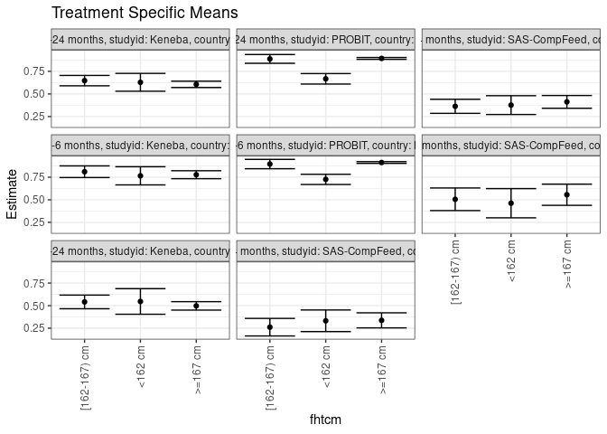

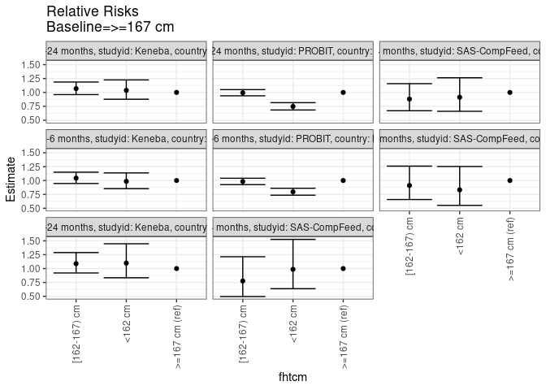

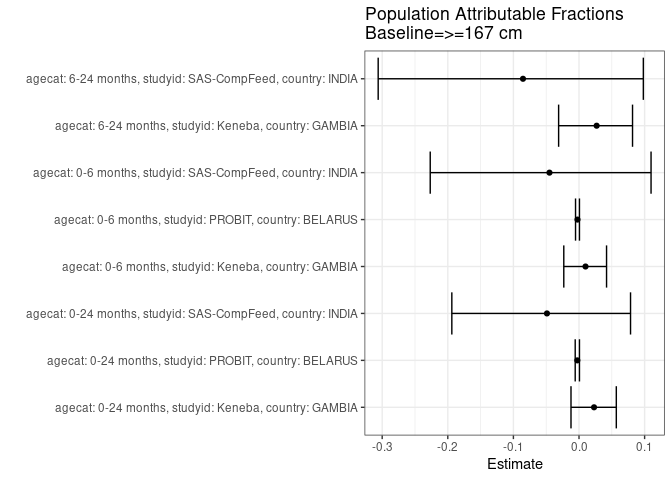

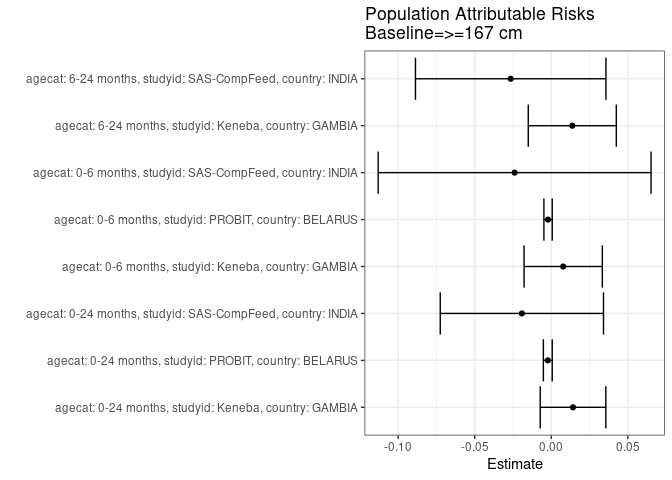

## Results Table

### Parameter: TSM

| agecat | studyid | country | intervention_level | baseline_level | estimate | ci_lower | ci_upper |
| --- | --- | --- | --- | --- | --- | --- | --- |
| 0-24 months | Keneba | GAMBIA | >=167 cm | NA | 0.6061228 | 0.5711450 | 0.6411006 |
| 0-24 months | Keneba | GAMBIA | <162 cm | NA | 0.6286151 | 0.5298828 | 0.7273473 |
| 0-24 months | Keneba | GAMBIA | [162-167) cm | NA | 0.6473873 | 0.5900288 | 0.7047459 |
| 0-24 months | PROBIT | BELARUS | >=167 cm | NA | 0.8933043 | 0.8828918 | 0.9037169 |
| 0-24 months | PROBIT | BELARUS | <162 cm | NA | 0.6675023 | 0.6092875 | 0.7257172 |
| 0-24 months | PROBIT | BELARUS | [162-167) cm | NA | 0.8877674 | 0.8391901 | 0.9363446 |
| 0-24 months | SAS-CompFeed | INDIA | >=167 cm | NA | 0.4122891 | 0.3416595 | 0.4829188 |
| 0-24 months | SAS-CompFeed | INDIA | <162 cm | NA | 0.3766346 | 0.2725701 | 0.4806992 |
| 0-24 months | SAS-CompFeed | INDIA | [162-167) cm | NA | 0.3632533 | 0.2853720 | 0.4411346 |
| 0-6 months | Keneba | GAMBIA | >=167 cm | NA | 0.7773763 | 0.7333379 | 0.8214147 |
| 0-6 months | Keneba | GAMBIA | <162 cm | NA | 0.7652211 | 0.6646009 | 0.8658412 |
| 0-6 months | Keneba | GAMBIA | [162-167) cm | NA | 0.8106245 | 0.7460147 | 0.8752342 |
| 0-6 months | PROBIT | BELARUS | >=167 cm | NA | 0.9124960 | 0.9026822 | 0.9223098 |
| 0-6 months | PROBIT | BELARUS | <162 cm | NA | 0.7258019 | 0.6695567 | 0.7820470 |
| 0-6 months | PROBIT | BELARUS | [162-167) cm | NA | 0.8955375 | 0.8438492 | 0.9472259 |
| 0-6 months | SAS-CompFeed | INDIA | >=167 cm | NA | 0.5557322 | 0.4383782 | 0.6730861 |
| 0-6 months | SAS-CompFeed | INDIA | <162 cm | NA | 0.4620027 | 0.3003940 | 0.6236114 |
| 0-6 months | SAS-CompFeed | INDIA | [162-167) cm | NA | 0.5056188 | 0.3806901 | 0.6305475 |
| 6-24 months | Keneba | GAMBIA | >=167 cm | NA | 0.4970144 | 0.4503538 | 0.5436750 |
| 6-24 months | Keneba | GAMBIA | <162 cm | NA | 0.5459754 | 0.4044305 | 0.6875202 |
| 6-24 months | Keneba | GAMBIA | [162-167) cm | NA | 0.5410377 | 0.4655410 | 0.6165343 |
| 6-24 months | SAS-CompFeed | INDIA | >=167 cm | NA | 0.3368397 | 0.2534264 | 0.4202530 |
| 6-24 months | SAS-CompFeed | INDIA | <162 cm | NA | 0.3321163 | 0.2126260 | 0.4516066 |
| 6-24 months | SAS-CompFeed | INDIA | [162-167) cm | NA | 0.2614502 | 0.1643464 | 0.3585540 |

### Parameter: E(Y)

| agecat | studyid | country | intervention_level | baseline_level | estimate | ci_lower | ci_upper |
| --- | --- | --- | --- | --- | --- | --- | --- |
| 0-24 months | Keneba | GAMBIA | NA | NA | 0.6203493 | 0.5920542 | 0.6486444 |
| 0-24 months | PROBIT | BELARUS | NA | NA | 0.8910364 | 0.8809112 | 0.9011616 |
| 0-24 months | SAS-CompFeed | INDIA | NA | NA | 0.3930886 | 0.3463071 | 0.4398700 |
| 0-6 months | Keneba | GAMBIA | NA | NA | 0.7851711 | 0.7510257 | 0.8193166 |
| 0-6 months | PROBIT | BELARUS | NA | NA | 0.9104046 | 0.9008342 | 0.9199750 |
| 0-6 months | SAS-CompFeed | INDIA | NA | NA | 0.5317919 | 0.4572362 | 0.6063476 |
| 6-24 months | Keneba | GAMBIA | NA | NA | 0.5107459 | 0.4734246 | 0.5480672 |
| 6-24 months | SAS-CompFeed | INDIA | NA | NA | 0.3103448 | 0.2551537 | 0.3655360 |

### Parameter: RR

| agecat | studyid | country | intervention_level | baseline_level | estimate | ci_lower | ci_upper |
| --- | --- | --- | --- | --- | --- | --- | --- |
| 0-24 months | Keneba | GAMBIA | >=167 cm | >=167 cm | 1.0000000 | 1.0000000 | 1.0000000 |
| 0-24 months | Keneba | GAMBIA | <162 cm | >=167 cm | 1.0371085 | 0.8776460 | 1.2255443 |
| 0-24 months | Keneba | GAMBIA | [162-167) cm | >=167 cm | 1.0680795 | 0.9610074 | 1.1870812 |
| 0-24 months | PROBIT | BELARUS | >=167 cm | >=167 cm | 1.0000000 | 1.0000000 | 1.0000000 |
| 0-24 months | PROBIT | BELARUS | <162 cm | >=167 cm | 0.7472283 | 0.6842971 | 0.8159470 |
| 0-24 months | PROBIT | BELARUS | [162-167) cm | >=167 cm | 0.9938017 | 0.9397372 | 1.0509767 |
| 0-24 months | SAS-CompFeed | INDIA | >=167 cm | >=167 cm | 1.0000000 | 1.0000000 | 1.0000000 |
| 0-24 months | SAS-CompFeed | INDIA | <162 cm | >=167 cm | 0.9135207 | 0.6603384 | 1.2637764 |
| 0-24 months | SAS-CompFeed | INDIA | [162-167) cm | >=167 cm | 0.8810645 | 0.6702018 | 1.1582702 |
| 0-6 months | Keneba | GAMBIA | >=167 cm | >=167 cm | 1.0000000 | 1.0000000 | 1.0000000 |
| 0-6 months | Keneba | GAMBIA | <162 cm | >=167 cm | 0.9843637 | 0.8530108 | 1.1359434 |
| 0-6 months | Keneba | GAMBIA | [162-167) cm | >=167 cm | 1.0427697 | 0.9460083 | 1.1494282 |
| 0-6 months | PROBIT | BELARUS | >=167 cm | >=167 cm | 1.0000000 | 1.0000000 | 1.0000000 |
| 0-6 months | PROBIT | BELARUS | <162 cm | >=167 cm | 0.7954027 | 0.7355578 | 0.8601166 |
| 0-6 months | PROBIT | BELARUS | [162-167) cm | >=167 cm | 0.9814153 | 0.9254617 | 1.0407518 |
| 0-6 months | SAS-CompFeed | INDIA | >=167 cm | >=167 cm | 1.0000000 | 1.0000000 | 1.0000000 |
| 0-6 months | SAS-CompFeed | INDIA | <162 cm | >=167 cm | 0.8313405 | 0.5519886 | 1.2520675 |
| 0-6 months | SAS-CompFeed | INDIA | [162-167) cm | >=167 cm | 0.9098246 | 0.6575763 | 1.2588360 |
| 6-24 months | Keneba | GAMBIA | >=167 cm | >=167 cm | 1.0000000 | 1.0000000 | 1.0000000 |
| 6-24 months | Keneba | GAMBIA | <162 cm | >=167 cm | 1.0985101 | 0.8342975 | 1.4463960 |
| 6-24 months | Keneba | GAMBIA | [162-167) cm | >=167 cm | 1.0885754 | 0.9203284 | 1.2875799 |
| 6-24 months | SAS-CompFeed | INDIA | >=167 cm | >=167 cm | 1.0000000 | 1.0000000 | 1.0000000 |
| 6-24 months | SAS-CompFeed | INDIA | <162 cm | >=167 cm | 0.9859772 | 0.6371744 | 1.5257221 |
| 6-24 months | SAS-CompFeed | INDIA | [162-167) cm | >=167 cm | 0.7761859 | 0.4965702 | 1.2132515 |

### Parameter: PAR

| agecat | studyid | country | intervention_level | baseline_level | estimate | ci_lower | ci_upper |
| --- | --- | --- | --- | --- | --- | --- | --- |
| 0-24 months | Keneba | GAMBIA | >=167 cm | NA | 0.0142265 | -0.0072029 | 0.0356559 |
| 0-24 months | PROBIT | BELARUS | >=167 cm | NA | -0.0022679 | -0.0051614 | 0.0006256 |
| 0-24 months | SAS-CompFeed | INDIA | >=167 cm | NA | -0.0192006 | -0.0725187 | 0.0341176 |
| 0-6 months | Keneba | GAMBIA | >=167 cm | NA | 0.0077948 | -0.0177675 | 0.0333570 |
| 0-6 months | PROBIT | BELARUS | >=167 cm | NA | -0.0020914 | -0.0048106 | 0.0006278 |
| 0-6 months | SAS-CompFeed | INDIA | >=167 cm | NA | -0.0239403 | -0.1130606 | 0.0651801 |
| 6-24 months | Keneba | GAMBIA | >=167 cm | NA | 0.0137315 | -0.0150237 | 0.0424866 |
| 6-24 months | SAS-CompFeed | INDIA | >=167 cm | NA | -0.0264949 | -0.0887047 | 0.0357149 |

### Parameter: PAF

| agecat | studyid | country | intervention_level | baseline_level | estimate | ci_lower | ci_upper |
| --- | --- | --- | --- | --- | --- | --- | --- |
| 0-24 months | Keneba | GAMBIA | >=167 cm | NA | 0.0229331 | -0.0122128 | 0.0568586 |
| 0-24 months | PROBIT | BELARUS | >=167 cm | NA | -0.0025452 | -0.0057993 | 0.0006982 |
| 0-24 months | SAS-CompFeed | INDIA | >=167 cm | NA | -0.0488454 | -0.1938441 | 0.0785425 |
| 0-6 months | Keneba | GAMBIA | >=167 cm | NA | 0.0099275 | -0.0232036 | 0.0419858 |
| 0-6 months | PROBIT | BELARUS | >=167 cm | NA | -0.0022972 | -0.0052899 | 0.0006865 |
| 0-6 months | SAS-CompFeed | INDIA | >=167 cm | NA | -0.0450181 | -0.2267770 | 0.1098114 |
| 6-24 months | Keneba | GAMBIA | >=167 cm | NA | 0.0268851 | -0.0310708 | 0.0815834 |
| 6-24 months | SAS-CompFeed | INDIA | >=167 cm | NA | -0.0853724 | -0.3061112 | 0.0980606 |